# Estimacion de Parametros

del modelo de Ornstein - Uhlenbeck

Diego

2024-12-01

El objetivo es poder utilizar este modelo para simular trayectorias futuras para observaciones de datos reales y poder usar el modelo para valuar activos como bonos a corto plazo. Al trabajar con datos reales, surgen inmediatamente 2 retos:

1. ```
   Determinar como vamos a estimar los parametros del modelo
   ```

2. ```
   Asegurarnos de que podemos confiar en nuestra estimacion de parametros
   ```

El segundo punto es muy importante, ya que como los parametros verdaderos seran desconocidos, si la estimacion es mala y proseguimos el analisis asumiendola como buena, toda conclusion sera potencialmente errada.

Hacemos enfasis en ello, porque la expresion de la verosimilitud del modelo es altamente compleja y el camino usual de:

- Derivar la log-verosimilitud con respecto a todos los parametros
- Evaluar cada derivada a 0
- Resolver el sistema de ecuaciones resultante

No lleva a nada en este caso o requiere un analisis extenso de dicho sistema de ecuaciones resultante y una buena cantidad de tiempo para invertir. En su lugar, utilizaremos **simulacion estocastica** para maximizar la log-verosimilitud tratandola como simplemente una funcion objetivo a maximizar en el espacio parametral de nuestros 3 parametros: $(\mu, \alpha, \sigma) \in \mathbb{R}^3$ . Mas concretamente, el espacio parametral matematicamente es:

$$\mathbb{R} \, \times \,\mathbb{R}^+ \times \,\mathbb{R}^+$$

aunque financieramente, tendria sentido que fuese ${(\mathbb{R}^+)}^3$. En cualquier caso, no es un espacio parametral sencillo y se vera que la expresion de la log verosimilitud tampoco lo es.

El metodo de Simulacion Estocastica que utilizaremos sera **Simulated Annealing**

## Log Verosimilitud

En una primera instancia, la primer idea acerca de como plantear la log verosimilitud pudiese ser partir de la expresion $r_t \sim N(\mu_t, \sigma_t^2)$ y comenzar escribiendo la log verosimilitud para una muestra de la distribucion normal y luego sustituir las expresiones $\mu_t$ y $sigma_t^2$. Sin embargo esto no puede hacerse asi directamente ya que estariamos violando una hipotesis importante en ese planteamiento que es que **la muestra debe ser iid** y en este caso la muestra no es independiente, ya que, en terminos simples: *el proceso $X_{t+ \Delta t}$ (al tiempo t) tiene una dependencia obvia de $X_{t}$.

Para manejar correctamente esta dependencia, usamos la estructura de la muestra de datos reales entorno a la cual buscamos definir la log verosimilitud. Recordemos que cada entrada i de los datos representa el proceso a tiempo $t_i$ y que entre cualquier tiempo y el siguiente existe la misma distancia de paso: $\Delta t$. Por ello aprovechamos esa estructura de los datos y la propiedad de homogeneidad en el tiempo del proceso para definir la log verosimilitud partiendo de la idea de la misma expresion que usamos para la simulacion de las trayectorias, que era:

$$X_{t} \, = \, \mu_{t} + \sigma_{t} \, Z_{t}$$

A partir de ahora, usaremos la parametrizacion del modelo de Ornstein Uhlenbeck en el campo de las finanzas, que como ya habiamos mencionado toma el nombre de **Modelo de Vasicek**. Asi, ahora escribimos $r_e$ en lugar de $\mu$, quedando la expresion de $\mu_t$ ahora escrita asi:

$$\mu_{t} \, = \, r_e + (X_{t-1} - r_e)\,e^{-\alpha \,\Delta t}$$

La expresion de $\sigma_t$ no cambia:

$$\sigma_{t} \, = \, \sigma \, \sqrt{\frac{1-e^{-2\alpha \, \Delta t}}{2
\alpha}}$$

Asi, podemos calcular correctamente la funcion de verosimilitud $L(\theta)$

$$L(\alpha,r_e, \sigma)\, = \, L(\theta)\, = \, f(x_0,x_1,...,x_n\, ;
\theta) \, =
\, f(x_0;\theta) \, \prod_{t=2}^{n}{ \frac{1}{\sqrt{2 \pi \,
\sigma_t^2}} exp\biggm(-\,\frac{(x_t-\mu_t)^2}{2\sigma_t^2}\biggm) }$$

en donde $\mu_t$ y $\sigma_t^2$ son las expresiones justo antes desarrolladas. Como el objetivo es maximizar, podemos de una vez despreciar la constante $f(x_0;\theta)$ .Observese que podria ahi sustituirse estas expresiones en la expresion completa de $L(\theta)$ pero realmente no ganamos nada, mas que terminar con una expresion larguisima y abrumadora de la verosimilitud, que despues habra que seguir manipulando y arrastrando

Ahora, aplicando logaritmo, la log verosimilitud $\mathcal{L}(\theta)$ es:

$$\mathcal{L}(\alpha,r_e, \sigma) \, = \, \mathcal{L}(\theta) \,= \,
log(L(\alpha,r_e, \sigma)\,) =
\sum_{t=2}^{n}{ log\biggm(\frac{1}{\sqrt{2 \pi \, \sigma_t^2}}
exp\biggm(-\,\frac{(x_t-\mu_t)^2}{2\sigma_t^2}\biggm)\,\, \biggm) } \,=$$

$$\sum_{t=2}^{n}{ log\biggm(\frac{1}{\sqrt{2 \pi}} \biggm) + \,log \biggm(
\frac{1}{\sqrt{\sigma_t^2}} \biggm) \, + \, log \biggm(
exp\biggm(-\,\frac{(x_t-\mu_t)^2}{2\sigma_t^2}\biggm)\,\, \biggm) }
\,=$$

$$\sum_{t=2}^n{ log\biggm(\,(2 \pi)^{-\frac{1}{2}}\,\biggm) +
\,log\biggm(\,(\sigma_t^2)^{-\frac{1}{2}}\,\biggm) \, - \,
\biggm(\frac{(x_t-\mu_t)^2}{2\sigma_t^2} \biggm)\, }$$

Por lo tanto, la expresion de la log verosimilitud con la que trabajaremos es:

$$\mathcal{L}(\alpha,r_e, \sigma) \, = \, \mathcal{L}(\theta) \, =
\,-\,\frac{n}{2}\,log(2\pi) + \sum_{t=2}^n{ -log(\sigma_t) \, - \,
\frac{1}{2} \biggm( \frac{x_t-\mu_t}{\sigma_t} \biggm)^2 }$$

```r
# datos debe ser un vector
log_verosimilitud <- function(theta, datos, dt){

  alpha <- theta[1]
  r_e   <- theta[2]
  sigma <- theta[3]
  r <- datos

  # alpha y sigma deben ser positivos (no pueden ni siquiera ser 0 o logL(theta) se indetermina)
  if (is.na(alpha) || is.na(sigma) || alpha <= 0 || sigma <= 0)    return(-1000)
  n <- length(datos) - 1     # porque en cada iteracion usaremos el indice i y i+1
  logL <- - n/2 * log(2*pi)    # inicializo en los terminos que no dependen del indice t

  for(t in 2:n){
    mu_t <- r_e + ( r[t-1] - r_e ) * exp(-alpha*dt)
    sigma_t <- sigma * sqrt( (1-exp(-2*alpha*dt)) / (2*alpha) )
    logL <- logL - log(sigma_t) - 1/2 * ( (r[t]-mu_t) / sigma_t )^2         # voy acumulando
  }
return(logL)
}
```

## Simulated Annealing

Ya con una expresion de la log verosimilitud, no es muy dificil darse cuenta de que el sistema de ecuaciones de las derivadas igualadas a 0 va a terminar siendo algo no lineal en el que el estimador maximo verosimil de cada uno de los parametos quedara en terminos no lineales (y dificiles o imposibles de despejar) de los otros parametros. Con solo una excepcion: El EMV de: $r_e$ que queda en terminos de $\alpha$. Esto lo retomaremos mas adelante, por ahora planteamos el algoritmo de **Simulated Annealing** de forma directa para maximizar la log verosimilitud:

```r
simulated_annealing_vasicek <- function( theta_0, datos, dt, freno){

  # Inicializo una variable que va a ir conservando solo los mejores conjuntos de parametros
  # para theta. Recordemos que theta = ( alpha, r_e, sigma )
  theta_actual <- theta_0
  logL_actual <- log_verosimilitud(theta_0,datos,dt)
  # parametros para modificar la escala de las distribuciones de propuesta de cada parametro de theta
  c1 <- 0.1
  #c2 <- 0.01
  c2 <- 0.004
  c3 <- 0.005
  # Creo una matriz para guardar los parametros y la log verosimilitud
  recorrido <- matrix(0,freno,4)
  colnames(recorrido) <- c("alpha","r_e","sigma","logL")
  recorrido[1,] <- c(theta_actual,logL_actual)

  # Comienza el Simulated Annealing
  for(i in 2:freno){
    #Temp <- 100/log(2*i)
    Temp <- 10/i
    # Simulo de theta propuesta de las distribuciones de propuesta
    alpha <- rnorm(1,theta_actual[1],c1)
    r_e   <- rnorm(1,theta_actual[2],c2)
    sigma <- rnorm(1,theta_actual[3],c3)
    theta_prop <- c(alpha,r_e,sigma)
    logL_prop <- log_verosimilitud(theta_prop,datos,dt)
    # Calculamos la probabilidad rho de aceptar el nuevo valor
    rho <- min(  exp( (logL_prop - logL_actual)/Temp ), 1  )
    if( runif(1) < rho ) {
        theta_actual <- theta_prop
        logL_actual <- logL_prop
    }
    recorrido[i,] <- c(theta_actual,logL_actual)
  }
  return(recorrido)
}
```

Ahora, probemos nuestro Simulated Annealing para ir evaluando ¿que tan bueno es? o ¿que tan malo es?

#### Experimento i

Tomemos la siguiente trayectoria simulada que corresponderian a datos observados por 3 semanas, 3 veces al dia:

- $t_f = 21$,
- $\Delta t = \frac{1}{3}$,
- $r_0 = 0.12$,
- $\theta \, = \, (\, \alpha, \, r_e, \, \sigma\, ) \, = \, (\, 0.30,\,0.20,\,0.08\,)$

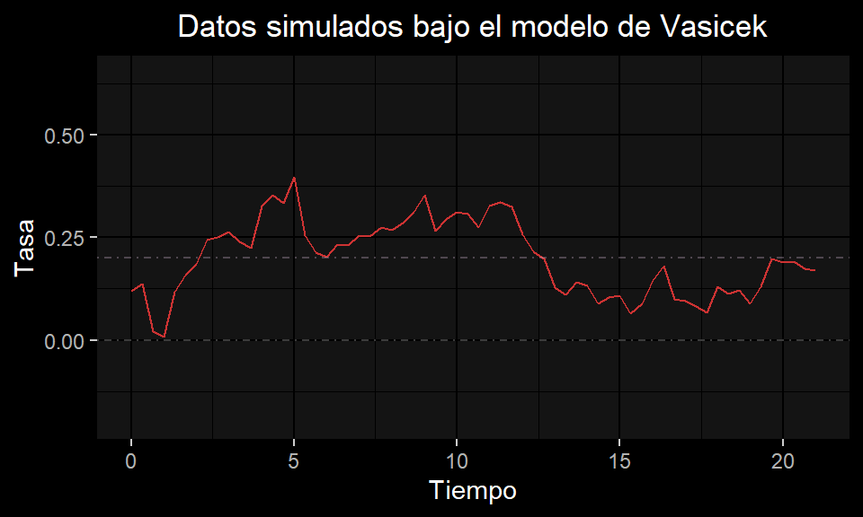

Tras realizar 4000 iteraciones del Simulated Annealing, los parametros que estimo el algoritmo son:

```
##                        alpha       r_e      sigma     logL
## iteraciones:  4000 0.4129853 0.2053931 0.08167583 104.3898
```

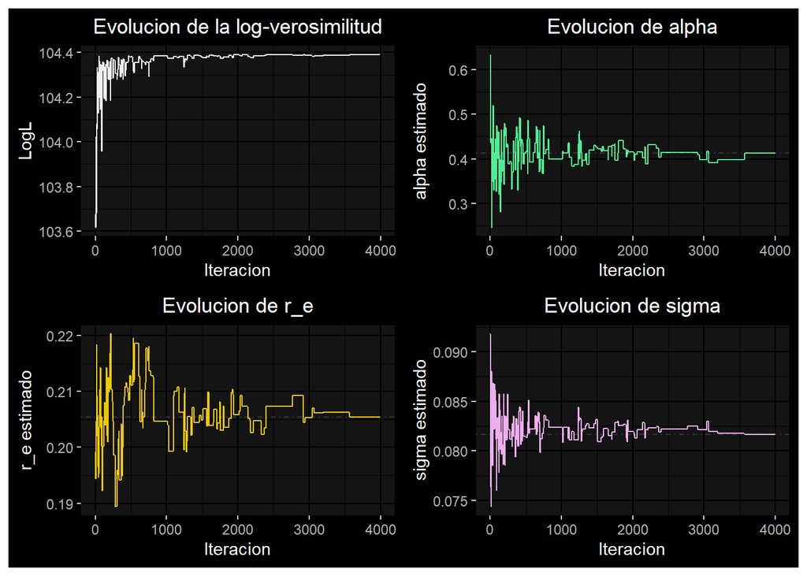

Vemos como los parametros $r_e, \, \sigma$ los estimo muy bien. $\alpha$ no lo estima estrepitosamente mal considerando lo subjetivo que es este parametro desde su interpretacion financiera: una “velocidad” en la que el proceso volvera a $r_e$ conforme t crezca.

Es importante observar que estamos estimando los parametros de una trayectoria con un horizonte temporal bastante corto, con 3 observaciones diarias. Por lo que es entendible que quiza el algoritmo no tuvo “suficientes” datos para estimar mejor.

Ahora otro experimento, a ver como se comporta el algoritmo cuando ampliamos el horizonte temporal y el tamaño del paso tambien. Son los mismos parametros, pero ahora en un horizonte temporal de 2 meses (61 dias) y una observacion diaria:

- $t_f = 60$,
- $\Delta t = 1$,
- $r_0 = 0.12$,
- $\theta \, = \, (\, \alpha, \, r_e, \, \sigma\, ) \, = \, (\, 0.30,\,0.20,\,0.08\,)$

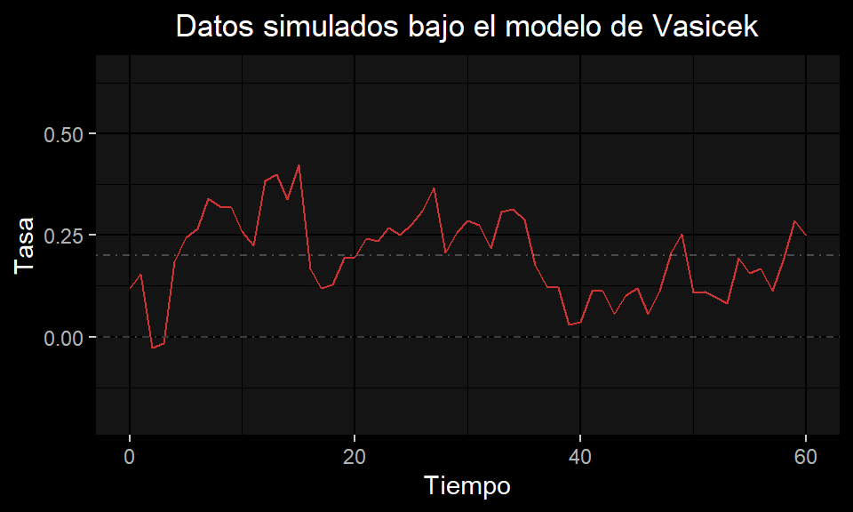

Tras realizar 4000 iteraciones, los estimadores puntuales que arroja el metodo son:

```
##                        alpha       r_e      sigma     logL
## iteraciones:  4000 0.3211592 0.2072573 0.08342174 70.94084
```

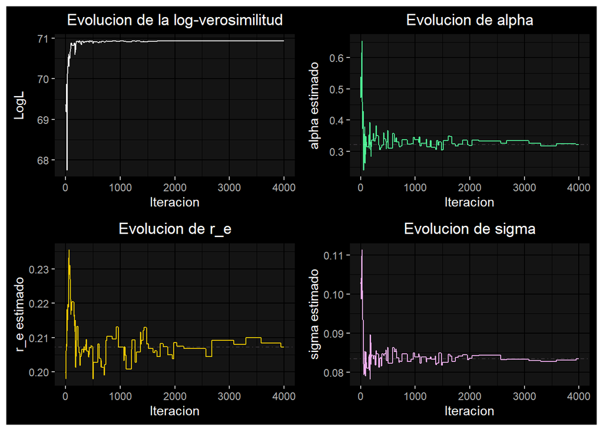

Vemos como, los parametros que ya estimaba muy bien el algoritmo los sigue estimando muy bien. Y el otro parametro ($\alpha$) ahora ya lo estima bien.

Ahora probemos el mismo experimento con un horizonte temporal aun mas grande: de medio año aproximadamente, manteniendo el tamaño de paso diario

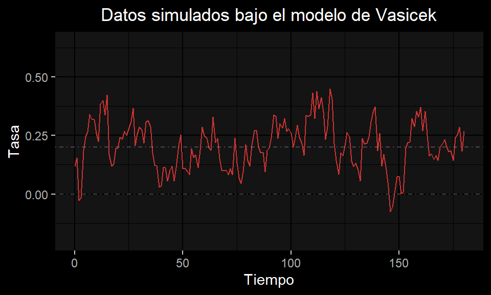

```
##                        alpha       r_e    sigma     logL
## iteraciones:  4000 0.3009193 0.2083055 0.079694 223.1392
```

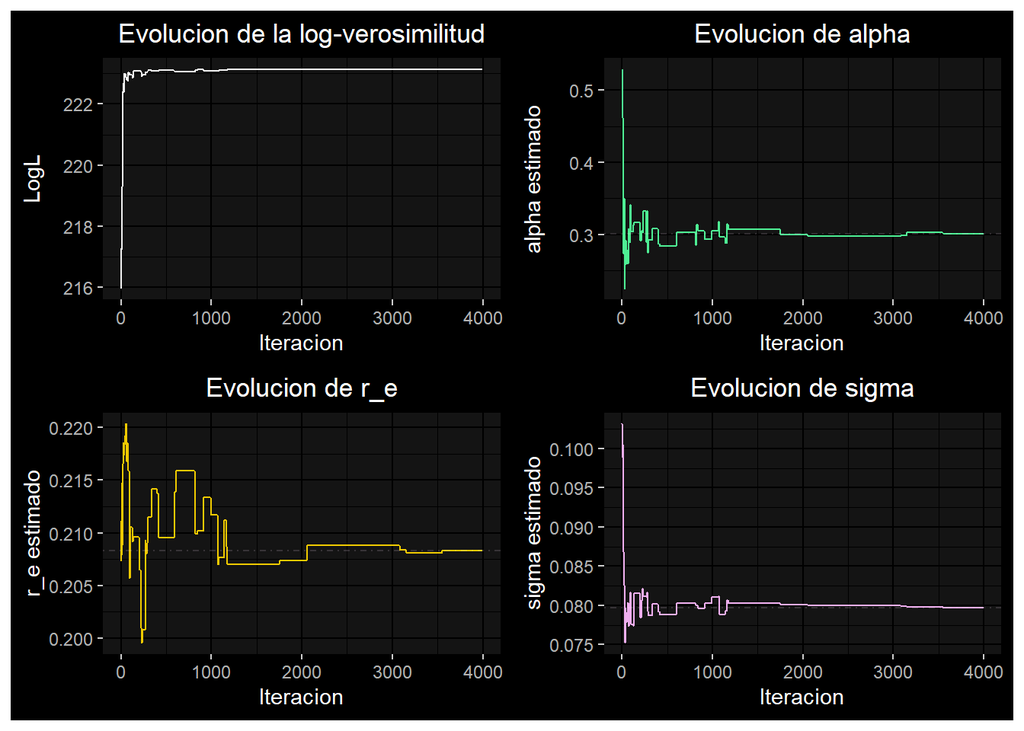

Parece que cuando el horizonte temporal es grande, los resultados del algoritmo son **altamenta satisfactorios**

Ahora, hagamos otro experimento ahora con un horizonte temporal grande (el mismo de medio año) pero un tamaño de paso muy pequeño 1/12, i.e una observacion cada 2 horas. Observese que eso significa tener $180 \cdot 12 = 2160$ puntos simulados de la trayectoria. ¿Una cantidad de datos tan grande provocara malas estimaciones?

- $t_f = 180$,
- $\Delta t = \frac{1}{12}$,
- $r_0 = 0.12$,
- $\theta \, = \, (\, \alpha, \, r_e, \, \sigma\, ) \, = \, (\, 0.30,\,0.20,\,0.08\,)$

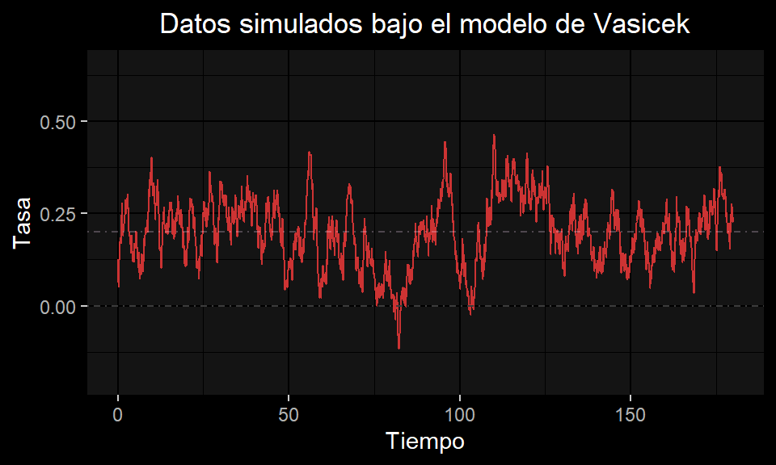

```
##                      alpha      r_e      sigma     logL
## iteraciones:  4000 0.36533 0.203745 0.07769359 5165.128
```

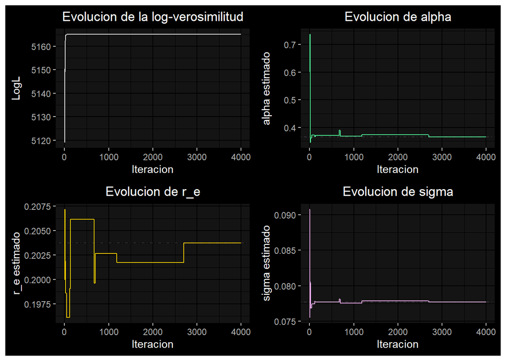

No! Persiste lo que veniamos observando: $r_e, \sigma$ siguen estimandose con extraordinaria precision y $\alpha$ se estima *“aceptablemente bien”*

[output not shown]

[figure not shown]

#### Experimento ii

Ahora: otra linea de experimentos: de vuelta a datos mensuales, pero con parametros mas dificiles de estimar , ya que la cadena tendera a visitar mas frecuentemente estados cercanos al 0

- $t_f = 30$,
- $\Delta t = 1$,
- $r_0 = 0.20$,
- $\theta \, = \, (\, \alpha, \, r_e, \, \sigma\, ) \, = \, (\, 0.40,\,0.10,\,0.06\,)$

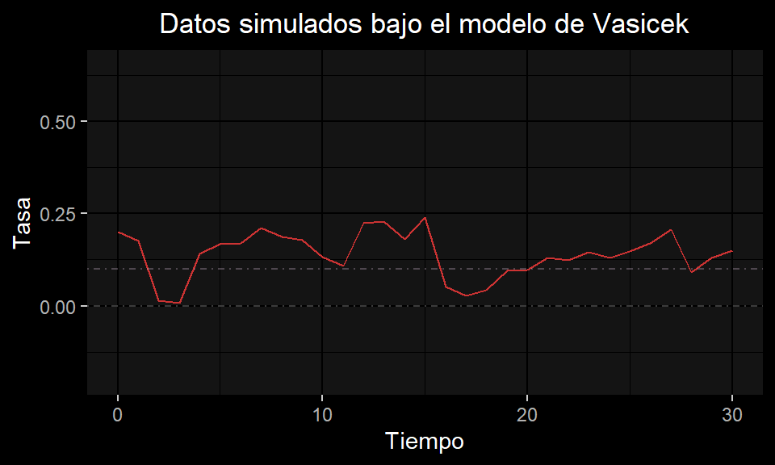

¿Y si ahora aumentamos el horizonte temporal a 2 meses?

- $t_f = 60$,
- $\Delta t = 1$,
- $r_0 = 0.20$,
- $\theta \, = \, (\, \alpha, \, r_e, \, \sigma\, ) \, = \, (\, 0.40,\,0.10,\,0.06\,)$

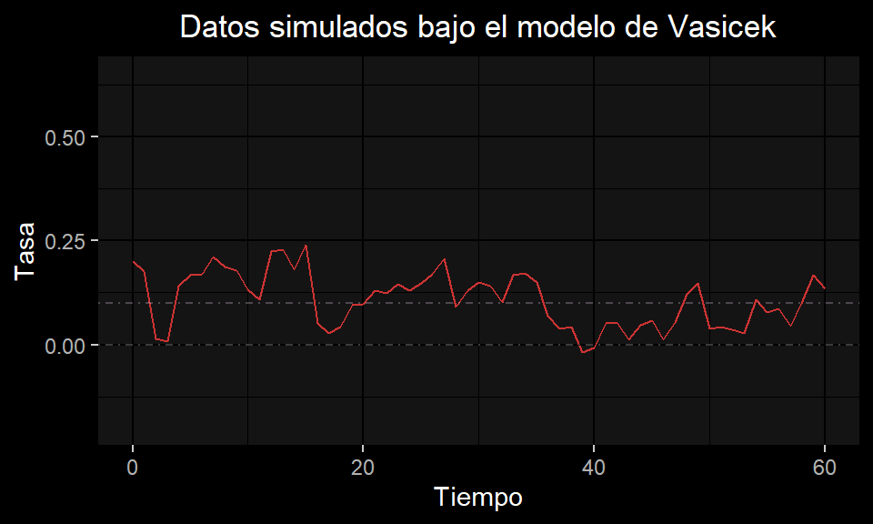

```
##                        alpha       r_e      sigma     logL
## iteraciones:  4000 0.4793616 0.1038429 0.06372339 90.61348
```

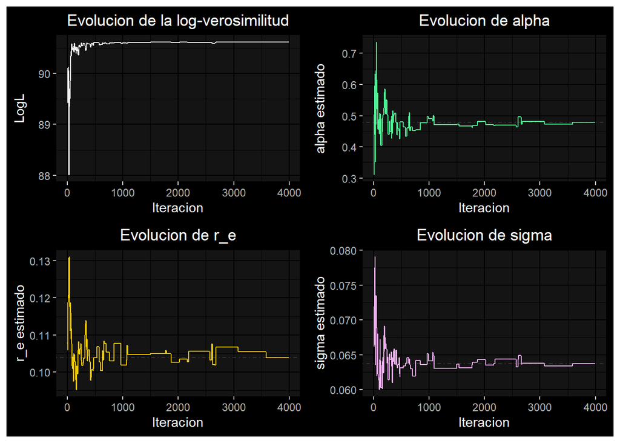

¿Y si en lugar de aumentar el horizonte temporal, disminuimos el tamaño de paso?

Ahora hagamos mas pequeño el tamaño de paso: a 2 observaciones por dia, a ver si mejoran las estimaciones

- $t_f = 30$,
- $\Delta t = \frac{1}{2}$,
- $r_0 = 0.20$,
- $\theta \, = \, (\, \alpha, \, r_e, \, \sigma\, ) \, = \, (\, 0.40,\,0.10,\,0.06\,)$

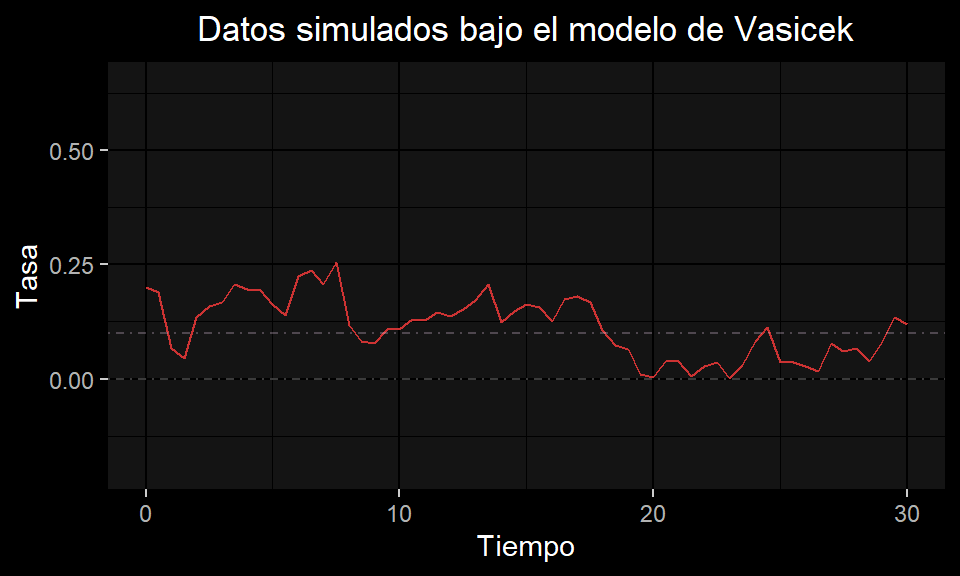

```
##                        alpha       r_e      sigma     logL
## iteraciones:  4000 0.4615089 0.1060893 0.06279043 105.7033
```

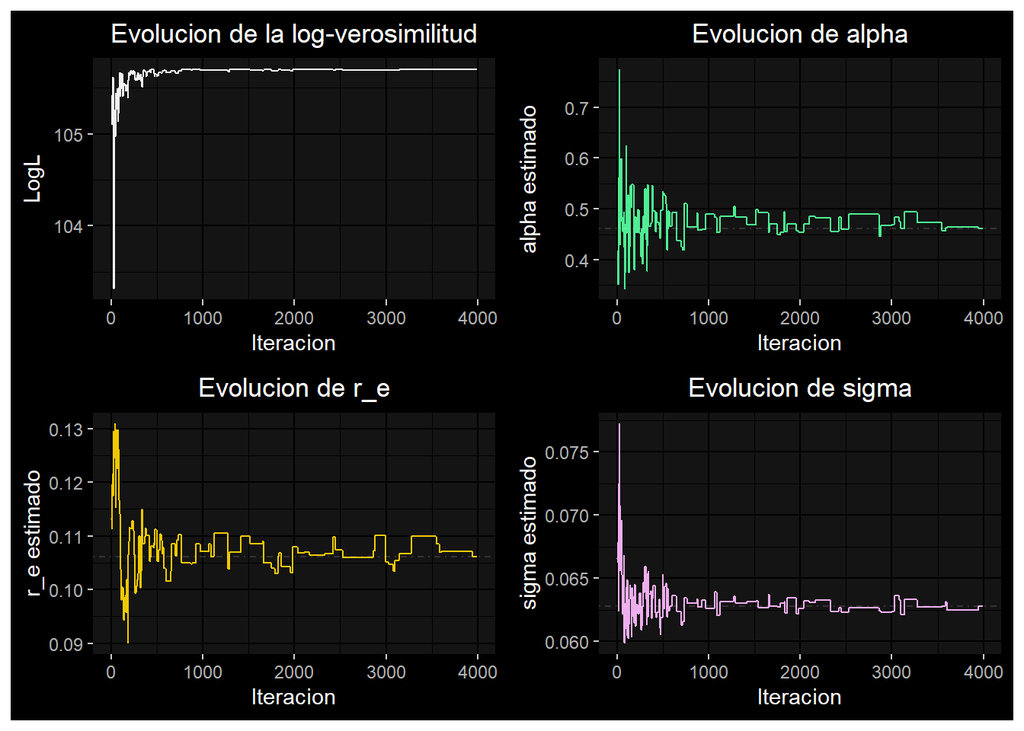

Ahora probemos ambas modificaciones: simular con un horizonte de 2 meses y con 2 observaciones por dia:

- $t_f = 60$,
- $\Delta t = \frac{1}{2}$,
- $r_0 = 0.20$,
- $\theta \, = \, (\, \alpha, \, r_e, \, \sigma\, ) \, = \, (\, 0.40,\,0.10,\,0.06\,)$

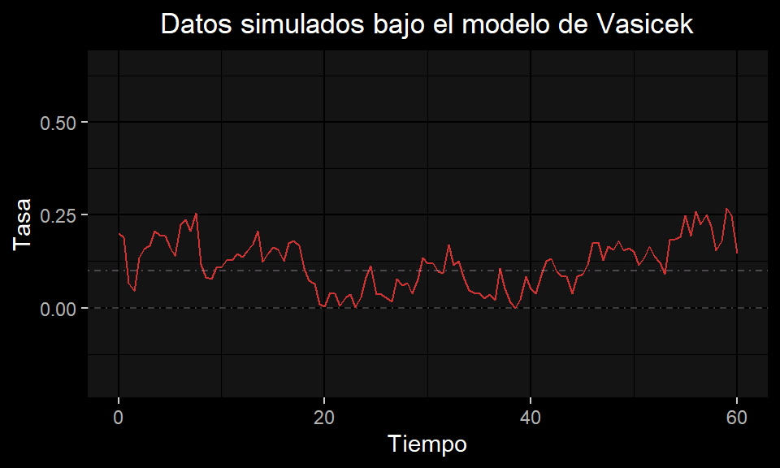

```
##                        alpha       r_e      sigma     logL
## iteraciones:  4000 0.3950937 0.1193009 0.06040135 217.4864
```

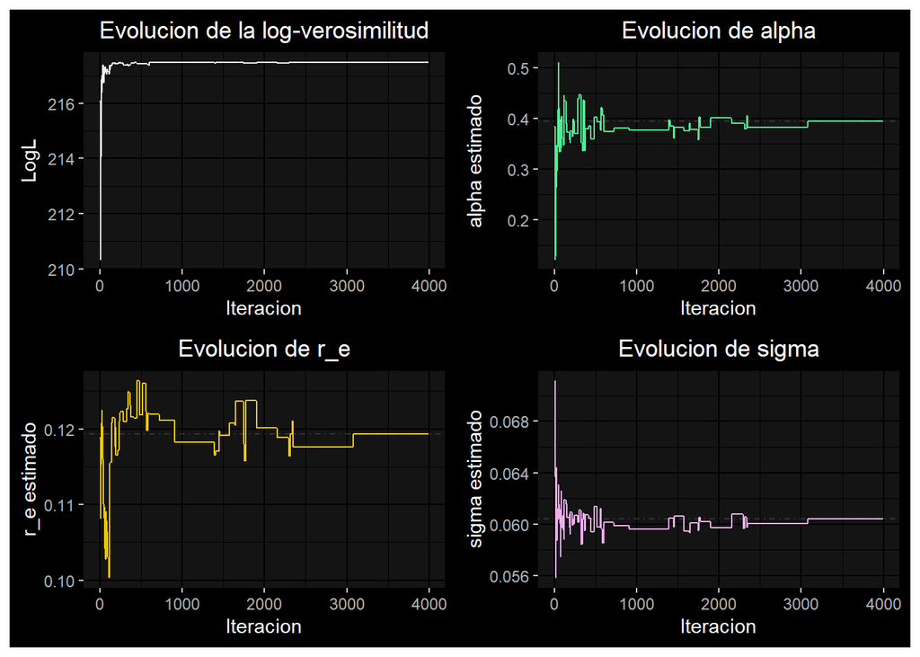

¿Perderemos consistencia si aumentamos de 2 meses a 3 meses mantendiendo las 2 observaciones por dia?

- $t_f = 90$,
- $\Delta t = \frac{1}{2}$,
- $r_0 = 0.20$,
- $\theta \, = \, (\, \alpha, \, r_e, \, \sigma\, ) \, = \, (\, 0.40,\,0.10,\,0.06\,)$

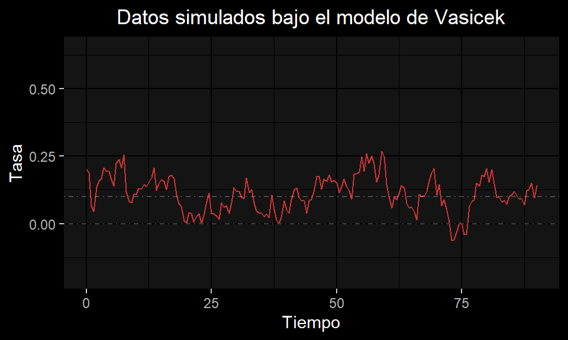

```
##                       alpha       r_e      sigma     logL
## iteraciones:  4000 0.407335 0.1058745 0.05997088 328.4708
```

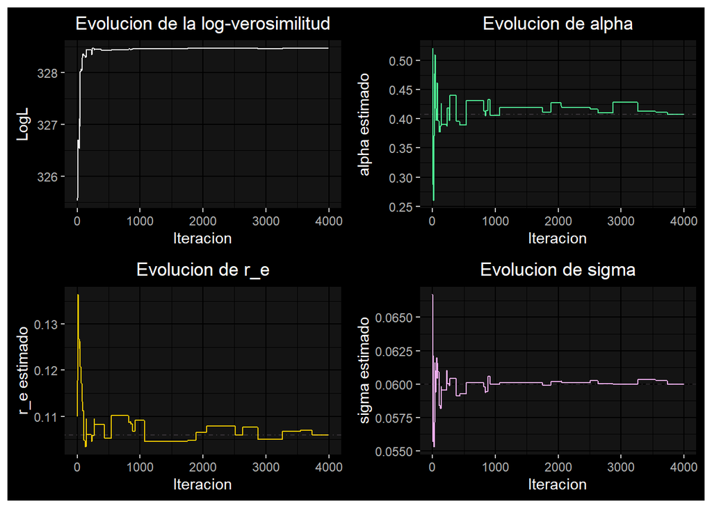

**¡No! Incluso mejoro un poco mas!**

#### Experimento iii

Probemos un experimento mas, ahora con un valor mucho mas alto para $\alpha$

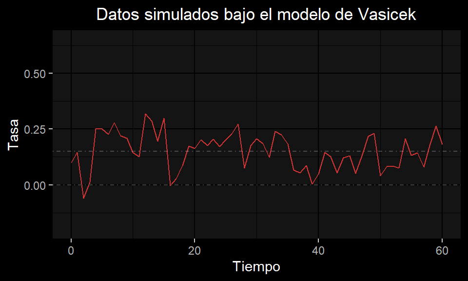

```
##                        alpha       r_e     sigma     logL
## iteraciones:  4000 0.9382259 0.1530873 0.1149927 66.38429
```

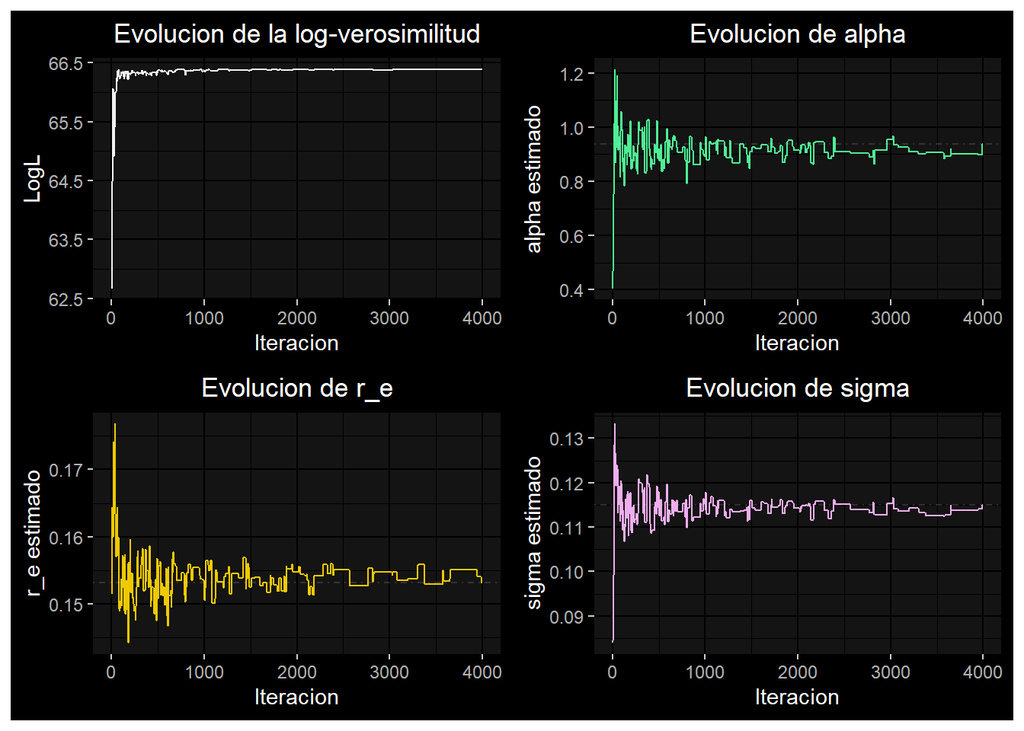

¡Una estimacion muy buena! Ahora disminuyendo a la mitad el tamaño de paso a ver si se mantiene la eficacia de las estimaciones

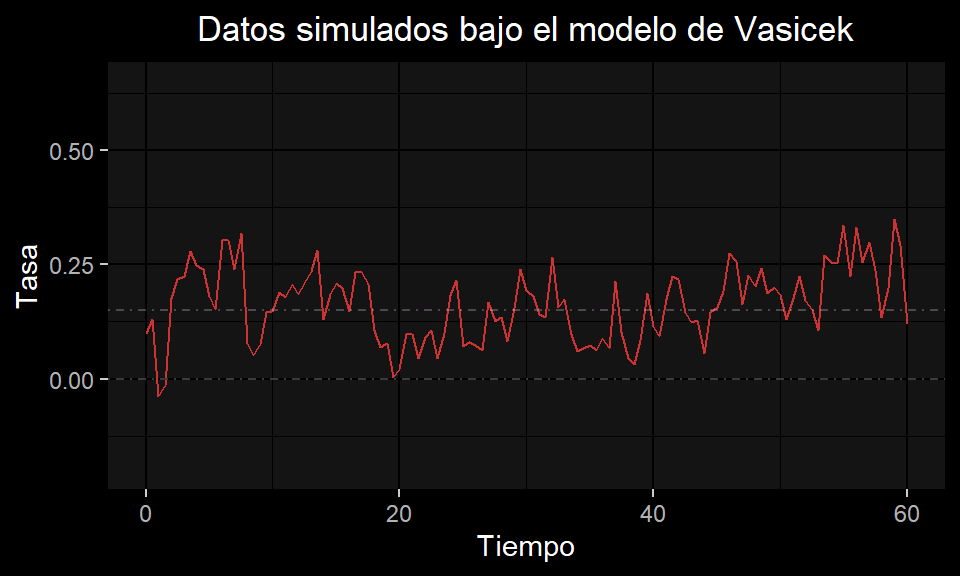

```
##                        alpha       r_e    sigma     logL
## iteraciones:  4000 0.9322609 0.1671432 0.111499 158.6429
```

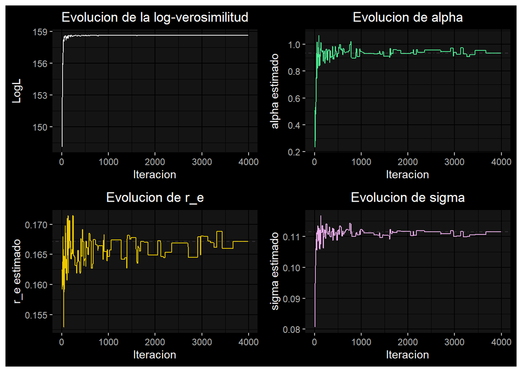

Las estimaciones son similarmente tan buenas como las anteriores

#### Experimento iv

Ahora un experimento con un valor especialmente grande para otro valor para $\sigma$, iniciando en un horizonte temporal de 1 mes y medio con observaciones diarias. Y despues 2 meses y medio.

- $t_f = 45$,
- $\Delta t = 1$,
- $r_0 = 0.20$,
- $\theta \, = \, (\, \alpha, \, r_e, \, \sigma\, ) \, = \, (\, 0.75,\,0.14,\,0.20\,)$

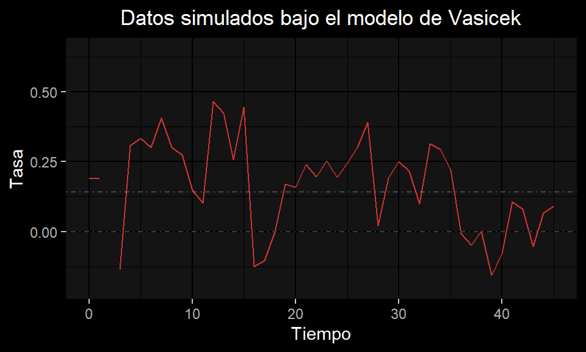

```
##                        alpha       r_e     sigma     logL
## iteraciones:  4000 0.7293237 0.1586795 0.2142456 18.94325
```

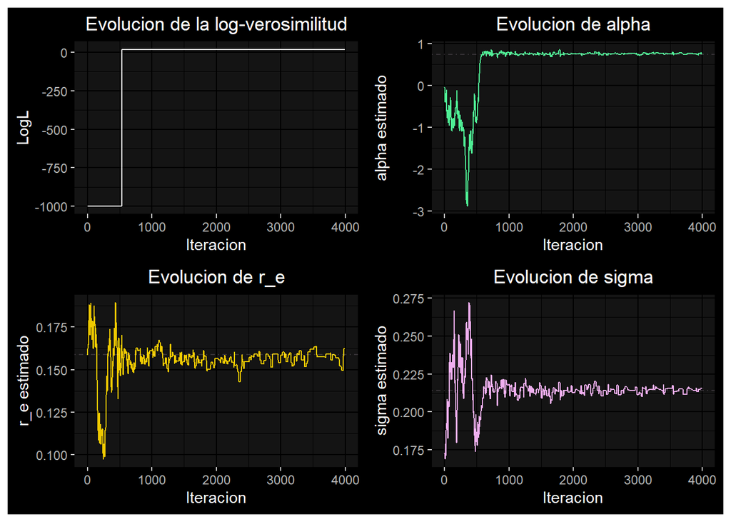

La estimacion es bastante buena.

- $t_f = 75$,
- $\Delta t = 1$,
- $r_0 = 0.20$,
- $\theta \, = \, (\, \alpha, \, r_e, \, \sigma\, ) \, = \, (\, 0.75,\,0.14,\,0.20\,)$

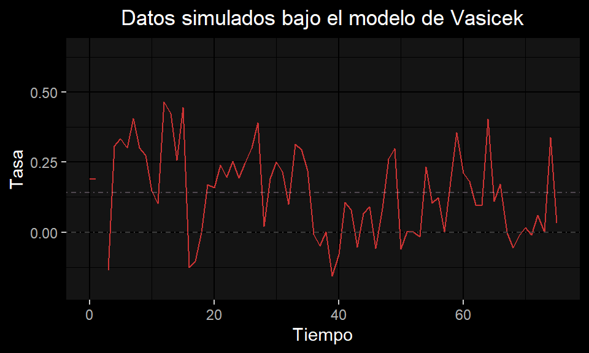

```
##                        alpha       r_e     sigma     logL
## iteraciones:  4000 0.8526216 0.1399895 0.2078199 37.15708
```

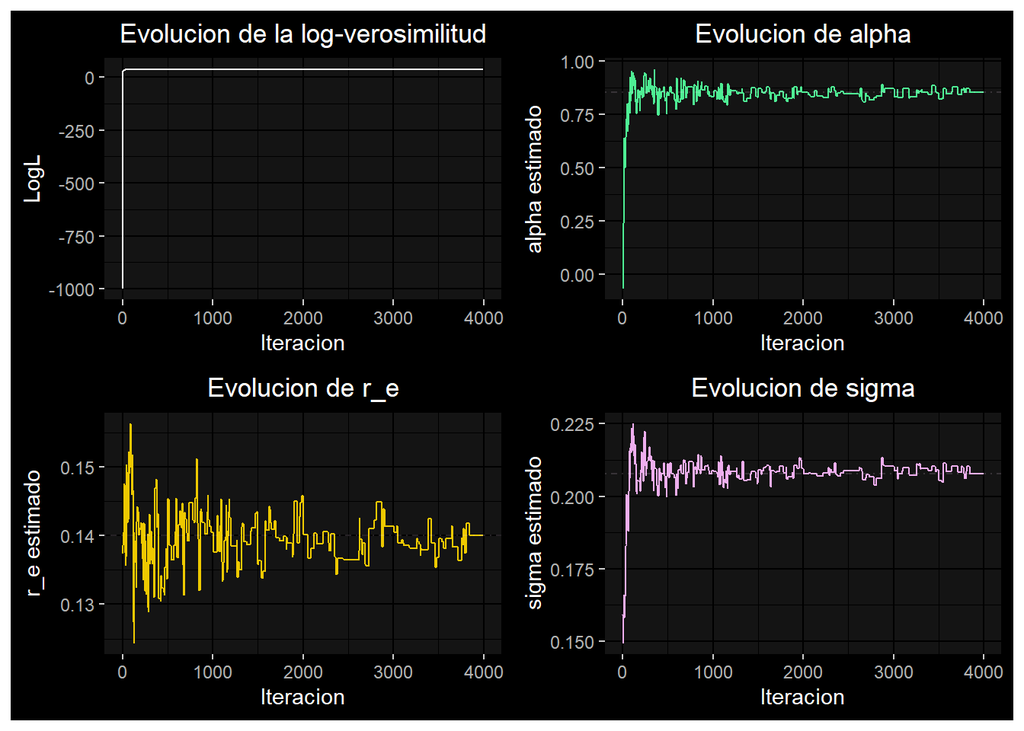

Las estimaciones para $r_e$ y $\sigma$ son *extraordinariamente buenas!**, la de $\alpha$ se alejo un poco de la real pero apesar de esto, no podria decirse que es muy mala. Mantengamos la temporalidad y disminuyamos a la mitad el tamaño de paso:

- $t_f = 75$,
- $\Delta t = \frac{1}{2}$,
- $r_0 = 0.20$,
- $\theta \, = \, (\, \alpha, \, r_e, \, \sigma\, ) \, = \, (\, 0.75,\,0.14,\,0.20\,)$

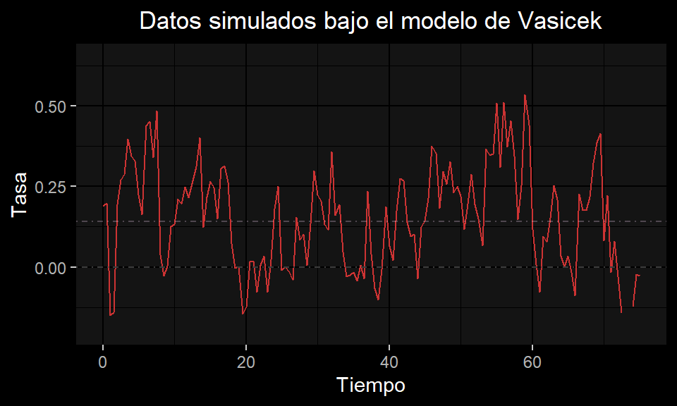

Vemos como trabajar con un valor tan alto de $\sigma$ tiene un efecto muy notorio en la dispersion del proceso. Las estimaciones del algoritmo son:

```
##                        alpha       r_e     sigma     logL
## iteraciones:  4000 0.7472562 0.1489154 0.2042932 101.7287
```

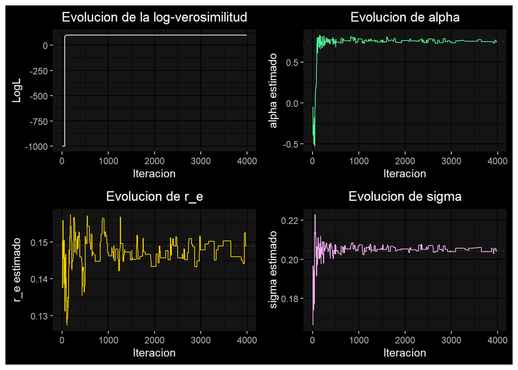

De nuevo, espectacularmente buenas.

#### Experimento v

- $t_f = 30$,
- $\Delta t = \frac{1}{24}$,
- $r_0 = 0.111$,
- $\theta \, = \, (\, \alpha, \, r_e, \, \sigma\, ) \, = \, (\, 0.65,\,0.20,\,0.10\,)$

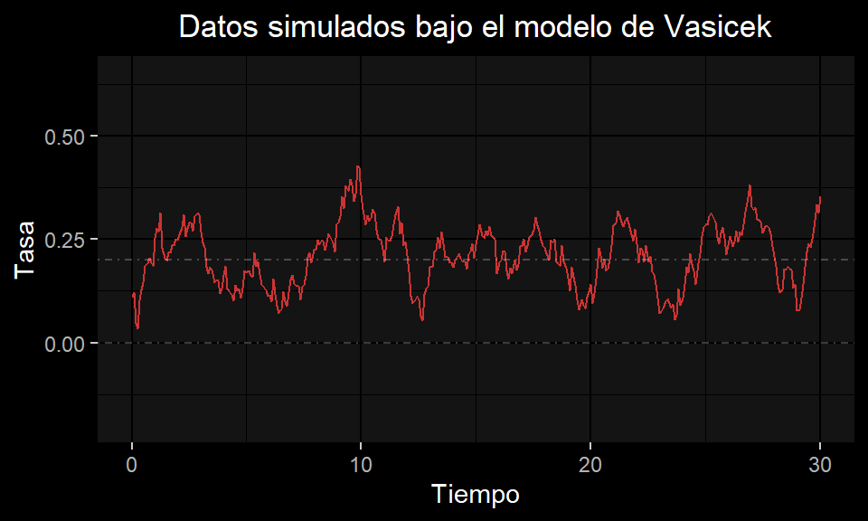

```
##                        alpha       r_e      sigma    logL
## iteraciones:  4000 0.9031128 0.2146215 0.09883175 778.393
```

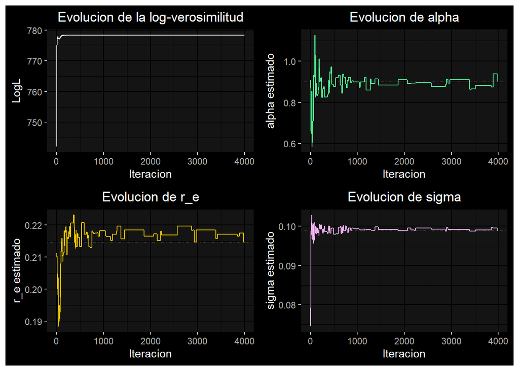

Tal como en los experimentos anteriores, la estimacion para $r_e$ y $\sigma$ es extraordinariamente buena. La de $\alpha$ no mucho. En los experimentos anteriores, cuando incrementamos el horizonte temporal, o cuando reducimos el tamaño de paso: las cosas mejoran. Hagamos el mismo experimento pero con observaciones cada 30 minutos

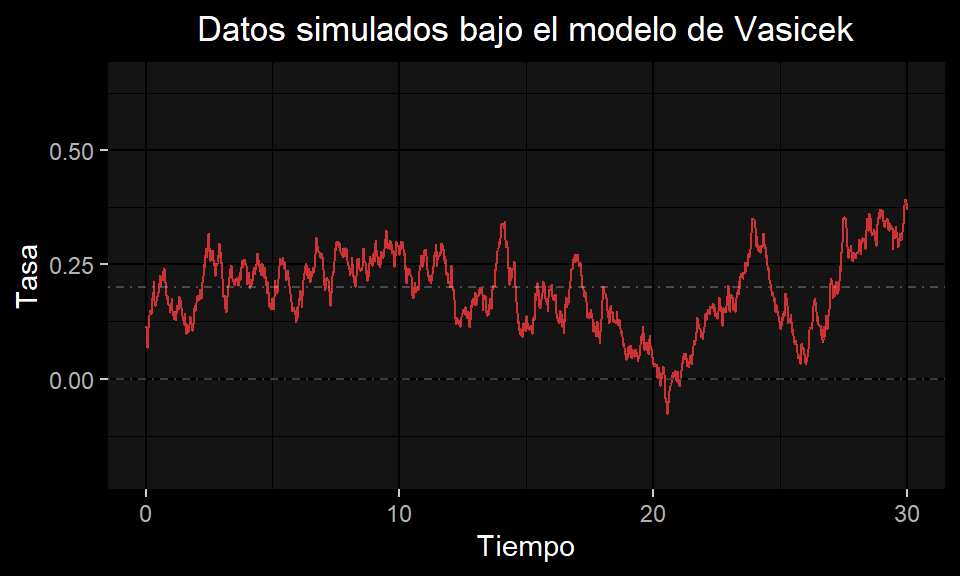

```
##                        alpha       r_e      sigma     logL
## iteraciones:  4000 0.5886939 0.2059805 0.09620194 4122.561
```

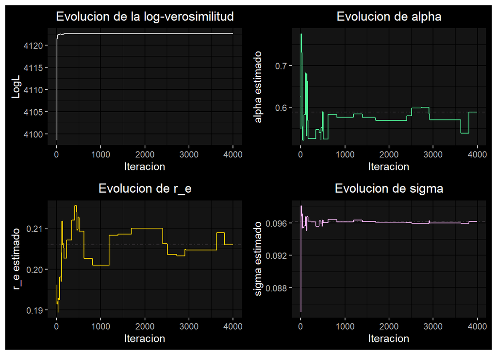